# Bankruptcy Prediction Using Machine Learning

Satya Vrat Singh

9 February 2019

# Abstract

The biggest calamity that can befall equity investors is corporate bankruptcy, which wipes out the equity of a firm and knocks the stock’s investment value down to zero. Fundamental analysis attempts to gauge the financial strength of a company using a variety of metrics. Used in conjunction with one another, financial ratios can often help us to paint a picture of the long-term viability of a firm.

- Clear the environment

```r
rm(list=ls(all=TRUE))
```

# Agenda

- Get the data
- Data Pre-processing
- Build models
- Predictions
- Analysis

# Understanding the Data

- The given data contains details of various markers and financial ratios of entities.  
  Target variable is whether the company got bankrupt in the subsequent years or not.
- 1 - bankrupt, 0 - not bankrup
- Make sure the dataset is located in your current working directory

```r
bank_data = read.csv("train.csv",header = T,
                     na.strings = c("?","#",""," ","NA"))
```

- Use the str(), summary() functions to get a feel for the dataset.

```r
str(bank_data)
```

```
## 'data.frame':    31283 obs. of  66 variables:
##  $ ID    : int  1 2 3 4 5 6 7 8 9 10 ...
##  $ Attr1 : num  0.13537 0.00586 0.1106 0.06391 0.13168 ...
##  $ Attr2 : num  0.452 0.399 0.161 1.407 0.66 ...
##  $ Attr3 : num  0.312 0.198 0.479 -0.296 0.441 ...
##  $ Attr4 : num  2.047 1.939 7.571 0.529 2.71 ...
##  $ Attr5 : num  10.23 9.58 263.9 -46.29 -23.6 ...
##  $ Attr6 : num  0.168 0 0 -0.714 -0.2 ...
##  $ Attr7 : num  0.16763 0.00724 0.13836 0.07907 0.13191 ...
##  $ Attr8 : num  1.213 1.509 5.205 -0.331 0.514 ...
##  $ Attr9 : num  2.255 0.979 0.684 0.985 2.136 ...
##  $ Attr10: num  0.548 0.601 0.839 -0.465 0.34 ...
##  $ Attr11: num  0.1833 0.0295 0.1388 0.0791 0.1861 ...
##  $ Attr12: num  0.5632 0.0344 1.8983 0.1258 0.5112 ...
##  $ Attr13: num  0.0892 0.0364 0.2362 0.0303 0.1671 ...
```

[output cut: 52 more lines]

```r
summary(bank_data)
```

```
##        ID            Attr1                Attr2
##  Min.   :    1   Min.   :-256.89000   Min.   :-430.8700
##  1st Qu.: 7822   1st Qu.:   0.00336   1st Qu.:   0.2694
##  Median :15642   Median :   0.04969   Median :   0.4727
##  Mean   :15642   Mean   :   0.05161   Mean   :   0.5512
##  3rd Qu.:23463   3rd Qu.:   0.13052   3rd Qu.:   0.6892
##  Max.   :31283   Max.   :  94.28000   Max.   : 480.7300
##                  NA's   :7            NA's   :7
##      Attr3               Attr4              Attr5
##  Min.   :-479.7300   Min.   :   -0.05   Min.   :-2722100.0
##  1st Qu.:   0.0221   1st Qu.:    1.05   1st Qu.:     -48.5
##  Median :   0.1968   Median :    1.57   Median :      -0.8
##  Mean   :   0.1512   Mean   :    7.32   Mean   :    -170.6
##  3rd Qu.:   0.4040   3rd Qu.:    2.80   3rd Qu.:      50.8
##  Max.   :  28.3360   Max.   :53433.00   Max.   : 1034100.0
##  NA's   :7           NA's   :102        NA's   :63
##      Attr6               Attr7               Attr8
##  Min.   :-508.1200   Min.   :-517.4800   Min.   :  -15.24
##  1st Qu.:   0.0000   1st Qu.:   0.0058   1st Qu.:    0.43
##  Median :   0.0000   Median :   0.0597   Median :    1.07
##  Mean   :  -0.0117   Mean   :   0.1206   Mean   :   14.38
##  3rd Qu.:   0.0876   3rd Qu.:   0.1519   3rd Qu.:    2.61
##  Max.   : 543.2500   Max.   : 649.2300   Max.   :53432.00
##  NA's   :7           NA's   :7           NA's   :73
##      Attr9              Attr10              Attr11
##  Min.   :  -3.496   Min.   :-479.7300   Min.   :-189.4500
##  1st Qu.:   1.018   1st Qu.:   0.2946   1st Qu.:   0.0153
##  Median :   1.197   Median :   0.5052   Median :   0.0756
##  Mean   :   2.784   Mean   :   0.7043   Mean   :   0.1632
##  3rd Qu.:   2.061   3rd Qu.:   0.7085   3rd Qu.:   0.1680
##  Max.   :9742.300   Max.   :1099.5000   Max.   : 681.5400
##  NA's   :4          NA's   :7           NA's   :32
##      Attr12              Attr13              Attr14
##  Min.   :-6331.800   Min.   :-1317.600   Min.   :-517.4800
##  1st Qu.:    0.015   1st Qu.:    0.024   1st Qu.:   0.0058
##  Median :    0.172   Median :    0.068   Median :   0.0597
##  Mean   :    1.260   Mean   :    0.925   Mean   :   0.1206
##  3rd Qu.:    0.589   3rd Qu.:    0.135   3rd Qu.:   0.1519
##  Max.   : 8259.400   Max.   :13315.000   Max.   : 649.2300
##  NA's   :102         NA's   :101         NA's   :7
```

[output cut: 121 more lines]

```
##  Min.   :    -12   Min.   :   -6.590   Min.   :  -14965
##  1st Qu.:      6   1st Qu.:    4.523   1st Qu.:      42
##  Median :     10   Median :    6.653   Median :      71
##  Mean   :    546   Mean   :   15.228   Mean   :    1641
##  3rd Qu.:     20   3rd Qu.:   10.418   3rd Qu.:     117
##  Max.   :4818700   Max.   :26862.000   Max.   :25016000
##  NA's   :1570      NA's   :73          NA's   :101
##      Attr63              Attr64              target
##  Min.   :   -0.368   Min.   :    -3.73   Min.   :0.0000
##  1st Qu.:    3.099   1st Qu.:     2.18   1st Qu.:0.0000
##  Median :    5.091   Median :     4.29   Median :0.0000
##  Mean   :    9.657   Mean   :    81.53   Mean   :0.0483
##  3rd Qu.:    8.619   3rd Qu.:     9.79   3rd Qu.:0.0000
##  Max.   :23454.000   Max.   :294770.00   Max.   :1.0000
##  NA's   :102         NA's   :601
```

# Exploratory Data Analysis

```r
table(bank_data$target)
```

```
##
##     0     1
## 29772  1511
```

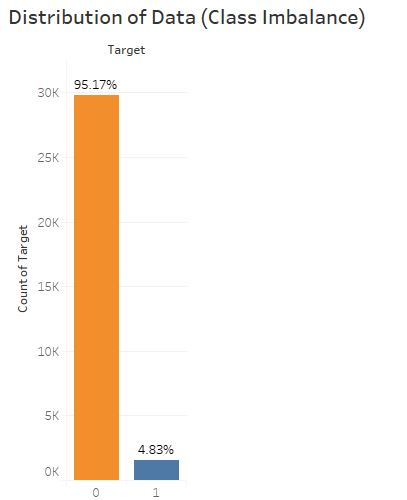

Have to do to stratified random sampling and SMOTE during/after split as the target variable is categirical and has class imbalance

# User-defined Functions

- knnimputation(data)
- CalScores_class(model,data)
- CalScores_response(model,data)

# Data Pre-processing

- Checking the number of missing values per column in the data frame

```r
colSums(is.na(bank_data))
```

```
##     ID  Attr1  Attr2  Attr3  Attr4  Attr5  Attr6  Attr7  Attr8  Attr9
##      0      7      7      7    102     63      7      7     73      4
## Attr10 Attr11 Attr12 Attr13 Attr14 Attr15 Attr16 Attr17 Attr18 Attr19
##      7     32    102    101      7     25     74     73      7    102
## Attr20 Attr21 Attr22 Attr23 Attr24 Attr25 Attr26 Attr27 Attr28 Attr29
##    101   4251      7    101    680      7     74   2004    601      7
## Attr30 Attr31 Attr32 Attr33 Attr34 Attr35 Attr36 Attr37 Attr38 Attr39
##    101    101    259    102     73      7      7  13768      7    101
## Attr40 Attr41 Attr42 Attr43 Attr44 Attr45 Attr46 Attr47 Attr48 Attr49
##    102    539    101    101    101   1566    102    207      8    101
## Attr50 Attr51 Attr52 Attr53 Attr54 Attr55 Attr56 Attr57 Attr58 Attr59
##     73      7    212    601    601      0    101      6     68      6
## Attr60 Attr61 Attr62 Attr63 Attr64 target
##   1570     73    101    102    601      0
```

- Drop the index column

```r
bank_data$target = as.factor(bank_data$target)
rownames(bank_data) <- bank_data$ID
bank_data$ID = NULL
```

- Train/Test Split

```r
set.seed(4470)
train_rows = createDataPartition(bank_data$target, p = 0.7, list = F)
train_data = bank_data[train_rows,] #training data
test_data = bank_data[-train_rows,] #test data
dim(bank_data)
```

```
## [1] 31283    65
```

```r
dim(train_data)
```

```
## [1] 21899    65
```

```r
dim(test_data)
```

```
## [1] 9384   65
```

```r
table(train_data$target)
```

```
##
##     0     1
## 20841  1058
```

```r
table(test_data$target)
```

```
##
##    0    1
## 8931  453
```

- Imputation

```r
train_data = knnimputation(train_data)
test_data = knnimputation(test_data)
sum(is.na(train_data))
```

```
## [1] 0
```

```r
sum(is.na(test_data))
```

```
## [1] 0
```

- Applying SMOTE to make class balanced

```r
set.seed(2232)
trainsmote = SMOTE(target~.,data=train_data,perc.over = 700,perc.under = 100 )
prop.table(table(trainsmote$target))
```

```
##
##         0         1
## 0.4666667 0.5333333
```

```r
set.seed(2232)
testsmote = SMOTE(target~.,data=test_data,perc.over = 700,perc.under = 100 )
```

# C50 Model

- Build model on smoteddata trainsmote

[figure not shown]

```r
DT_C50 <- C5.0(target~.,data=trainsmote)
plot(DT_C50)
```

* Check variable importance

```r
C5imp(DT_C50, pct=TRUE)
```

```
##        Overall
## Attr26  100.00
## Attr27   81.93
## Attr6    81.07
## Attr64   76.30
## Attr5    71.64
## Attr29   64.64
## Attr37   62.87
## Attr46   54.77
## Attr34   52.73
## Attr47   48.26
## Attr15   44.28
## Attr53   29.42
## Attr50   26.98
## Attr13   25.67
## Attr61   23.14
## Attr9    22.17
## Attr24   20.36
## Attr51   19.68
## Attr3    18.75
## Attr52   17.45
## Attr41   16.95
## Attr21   16.45
## Attr59   13.72
## Attr4    13.67
## Attr60   11.92
## Attr35   11.35
## Attr25   11.12
## Attr40   10.05
## Attr58    9.44
## Attr38    9.27
## Attr48    8.17
## Attr42    7.60
## Attr12    7.29
## Attr30    7.11
## Attr45    7.02
## Attr19    5.09
## Attr49    4.83
## Attr11    4.44
## Attr28    4.24
```

[output cut: 10 more lines]

```
## Attr17    1.56
## Attr22    1.41
## Attr43    1.40
## Attr31    1.11
## Attr63    1.10
## Attr23    1.05
## Attr7     1.01
## Attr32    0.94
## Attr2     0.79
## Attr36    0.77
## Attr56    0.61
## Attr33    0.40
## Attr14    0.00
## Attr18    0.00
## Attr62    0.00
```

- Perforance metric

```r
CalScores_class(DT_C50,trainsmote)
```

```
##           Reference
## Prediction    0    1
##          0 7179  227
##          1  191 8273
##
## Recall      :  0.9740841
## Precision   :  0.9693492
## Specificity :  0.9732941
## Accuracy    :  0.973661
## F1 Score    :  0.9717109
```

```r
CalScores_class(DT_C50,testsmote)
```

```
##           Reference
## Prediction    0    1
##          0 2678  493
##          1 1157 2467
##
## Recall      :  0.6983051
## Precision   :  0.8445285
## Specificity :  0.8334459
## Accuracy    :  0.7571744
## F1 Score    :  0.7644876
```

# RPART Model

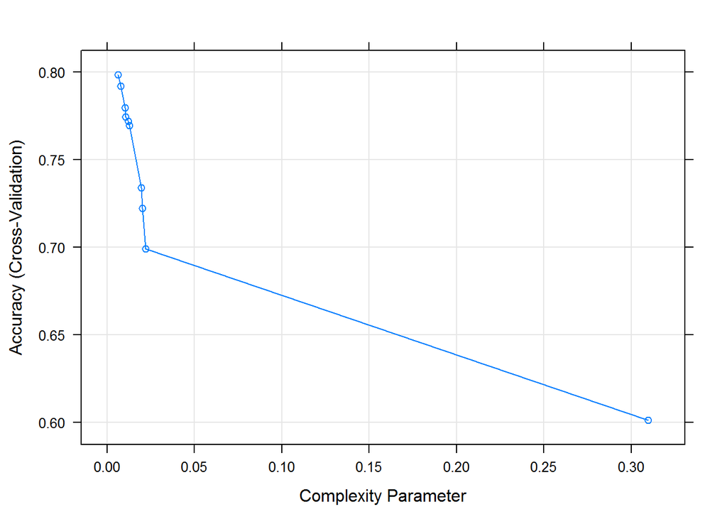

```r
DT_rpart <- train(target ~., data = trainsmote, method = "rpart",
  trControl = trainControl("cv", number = 10),
  tuneLength = 10 #tuneLength, to specify the number of possible cp values to evaluate. Default value is 3, here we'll use 10.
)

plot(DT_rpart) #cp 0.00405077
```

```r
DT_rpart$bestTune
```

```
##            cp
## 1 0.006346206
```

- Perforance metric

```r
CalScores_class(DT_rpart$finalModel,trainsmote)
```

```
##           Reference
## Prediction    0    1
##          0 5757 1649
##          1 1510 6954
##
## Recall      :  0.7922114
## Precision   :  0.7773427
## Specificity :  0.8083227
## Accuracy    :  0.8009452
## F1 Score    :  0.7847066
```

```r
CalScores_class(DT_rpart$finalModel,testsmote)
```

```
##           Reference
## Prediction    0    1
##          0 2486  685
##          1 1002 2622
##
## Recall      :  0.7127294
## Precision   :  0.7839798
## Specificity :  0.7928636
## Accuracy    :  0.7517292
## F1 Score    :  0.7466587
```

# Random Forest

```r
set.seed(123)
DT_RF = randomForest(target ~ .,
                     data=trainsmote,
                     keep.forest=TRUE,
                     ntree=200,
                     set.seed(123)
)
DT_RF$importance
```

```
##        MeanDecreaseGini
## Attr1          77.65953
## Attr2          95.98949
## Attr3          68.79832
## Attr4          66.49236
## Attr5         160.81562
## Attr6         315.29828
## Attr7          78.20827
## Attr8          68.39406
## Attr9         109.67652
## Attr10        112.60123
## Attr11         87.12602
## Attr12        205.42448
## Attr13        130.08152
## Attr14         65.89217
## Attr15        103.62449
## Attr16        184.82409
## Attr17         76.88626
## Attr18         92.44436
## Attr19         83.51595
## Attr20         90.28138
## Attr21         99.17948
## Attr22        123.86875
## Attr23         78.32849
## Attr24        376.47312
## Attr25        213.36396
## Attr26        206.67721
## Attr27        571.49240
## Attr28         81.67156
## Attr29        158.88685
## Attr30         67.54259
## Attr31         72.53546
## Attr32         54.75240
## Attr33         66.05826
## Attr34        229.33600
## Attr35        123.52117
## Attr36         78.26601
## Attr37        267.69954
## Attr38        169.23961
## Attr39        193.87548
```

[output cut: 10 more lines]

```
## Attr50         72.91720
## Attr51         97.86384
## Attr52         51.99407
## Attr53         75.73344
## Attr54         74.28756
## Attr55        105.53450
## Attr56        101.27632
## Attr57         73.92981
## Attr58        149.81320
## Attr59        108.72830
## Attr60         95.03047
## Attr61         99.45252
## Attr62         64.01474
## Attr63         55.50531
## Attr64        107.11266
```

```r
rf_Imp_Attr = data.frame(DT_RF$importance)
rf_Imp_Attr = data.frame(Attributes = row.names(rf_Imp_Attr), Importance = rf_Imp_Attr[,1])
rf_Imp_Attr = rf_Imp_Attr[order(rf_Imp_Attr$Importance, decreasing = TRUE),]
rf_Imp_Attr
```

```
##    Attributes Importance
## 27     Attr27  571.49240
## 24     Attr24  376.47312
## 6       Attr6  315.29828
## 37     Attr37  267.69954
## 46     Attr46  254.80497
## 34     Attr34  229.33600
## 25     Attr25  213.36396
## 26     Attr26  206.67721
## 12     Attr12  205.42448
## 39     Attr39  193.87548
## 16     Attr16  184.82409
## 38     Attr38  169.23961
## 5       Attr5  160.81562
## 29     Attr29  158.88685
```

[output cut: 50 more lines]

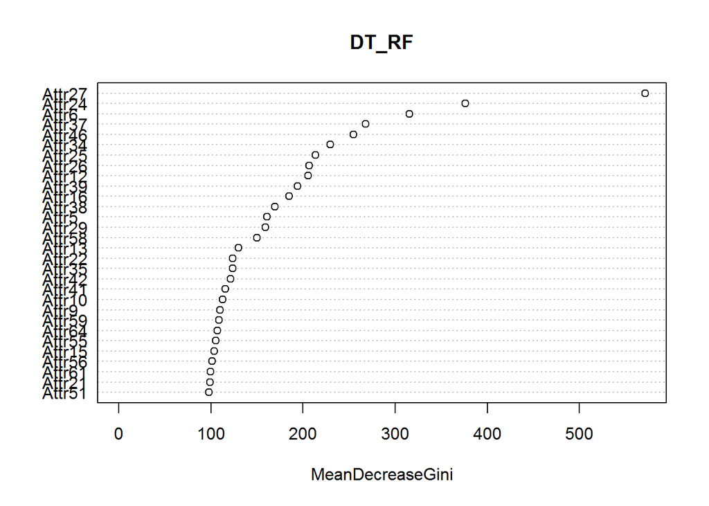

```r
varImpPlot(DT_RF)
```

- Perforance metric

```r
CalScores_response(DT_RF,testsmote)
```

```
##          Prediction
## Reference    0    1
##         0 2927  979
##         1  244 2645
##
## Recall      :  0.9230527
## Precision   :  0.74936
## Specificity :  0.7298565
## Accuracy    :  0.8200147
## F1 Score    :  0.8271867
```

### RF Important Attr

```r
top_Imp_Attr = as.character(rf_Imp_Attr$Attributes[1:35])
DT_RF_Imp = randomForest(target~.,
                         data=trainsmote[,c(top_Imp_Attr,"target")],
                         keep.forest=TRUE,
                         ntree=100, set.seed(015)
)
CalScores_response(DT_RF_Imp,testsmote)
```

```
##          Prediction
## Reference    0    1
##         0 2943  932
##         1  228 2692
##
## Recall      :  0.9280984
## Precision   :  0.7594839
## Specificity :  0.7428256
## Accuracy    :  0.8292862
## F1 Score    :  0.8353676
```

- Fine tuning parameters of Random Forest model
- Using For loop to identify the right mtry for model

```r
#a=c()
#i=11
#for (i in 10:20) {
#  model3 <- randomForest(target ~ ., data = trainsmote, ntree = 500, mtry = i, importance = TRUE)
#  predValid <- predict(model3, testsmote, type = "class")
#  a[i-2] = mean(predValid == testsmote$target)
#}
#a
#plot(10:20,a)
```

- Random Forest with mtry=19

```r
RF_tune  <- randomForest(target~., data = trainsmote, ntree = 500, mtry = 19, importance = TRUE, set.seed(2345))
CalScores_response(RF_tune,testsmote)
```

```
##          Prediction
## Reference    0    1
##         0 2929  928
##         1  242 2696
##
## Recall      :  0.9236834
## Precision   :  0.7593985
## Specificity :  0.7439294
## Accuracy    :  0.8278146
## F1 Score    :  0.8335231
```

- Random Forest Feature selection

```r
RF_tune$importance
```

```
##                  0           1 MeanDecreaseAccuracy MeanDecreaseGini
## Attr1  0.010147646 0.014797557          0.012627460         50.44473
## Attr2  0.015410935 0.014189926          0.014763239         54.40880
## Attr3  0.005905207 0.010682168          0.008446382         55.51534
## Attr4  0.004322352 0.010682672          0.007712161         51.08528
## Attr5  0.010362068 0.036284164          0.024179578        178.50724
## Attr6  0.046458137 0.076277322          0.062349801        404.98333
## Attr7  0.006269549 0.014078709          0.010434398         41.37033
## Attr8  0.008832887 0.007634359          0.008198345         50.66611
## Attr9  0.014768765 0.025578786          0.020528381        113.95795
## Attr10 0.021941307 0.016356151          0.018976004         73.11195
## Attr11 0.007664855 0.021291148          0.014920835         57.18953
## Attr12 0.017159528 0.035366800          0.026866895        138.90277
## Attr13 0.018141754 0.028106992          0.023454519        102.46480
## Attr14 0.007986821 0.014076987          0.011232850         44.20703
## Attr15 0.047072067 0.006517641          0.025447889         97.95032
## Attr16 0.037506928 0.052419840          0.045444280        283.59116
## Attr17 0.007684273 0.008286425          0.008000614         52.36979
## Attr18 0.007524400 0.013166802          0.010532243         41.99972
## Attr19 0.007067704 0.015967013          0.011810868         49.04913
## Attr20 0.009131133 0.014013161          0.011729388         84.19707
## Attr21 0.004120894 0.012177796          0.008415416         97.19372
## Attr22 0.008850262 0.027967186          0.019031761         85.00113
## Attr23 0.012243874 0.013282412          0.012804371         49.82937
## Attr24 0.046981243 0.077681036          0.063336118        406.32439
## Attr25 0.014121911 0.034287229          0.024870523        179.56138
## Attr26 0.046843080 0.070444636          0.059429326        378.78869
## Attr27 0.114104014 0.160683587          0.138920419        726.65859
## Attr28 0.005856537 0.010812194          0.008499300         67.95806
## Attr29 0.008865267 0.038884934          0.024862580        174.01325
## Attr30 0.006347016 0.013660440          0.010239875         60.83830
## Attr31 0.008765601 0.015771345          0.012496290         57.91387
## Attr32 0.005781632 0.006307473          0.006059807         40.11626
## Attr33 0.003231233 0.007998570          0.005772930         51.49408
## Attr34 0.050179796 0.062038056          0.056491882        359.87540
## Attr35 0.015682580 0.062003906          0.040370711        142.76615
## Attr36 0.005083485 0.010532126          0.007986897         72.22749
## Attr37 0.031573988 0.056032064          0.044612911        348.97559
## Attr38 0.032522569 0.035545033          0.034127895        172.19690
## Attr39 0.022511559 0.084262115          0.055408723        197.55272
```

[output cut: 10 more lines]

```
## Attr50 0.004066052 0.012313239          0.008461594         59.01154
## Attr51 0.019013916 0.015551728          0.017169457         85.76179
## Attr52 0.003120651 0.004471343          0.003841534         34.72947
## Attr53 0.007734372 0.009318452          0.008575659         65.18589
## Attr54 0.006726241 0.007836045          0.007319456         59.17512
## Attr55 0.005418442 0.020029932          0.013195659         96.29119
## Attr56 0.017515913 0.010528074          0.013794893         97.55384
## Attr57 0.007102856 0.006021951          0.006527077         61.65390
## Attr58 0.024468543 0.021107345          0.022678964        148.98852
## Attr59 0.013198949 0.023728986          0.018810380        122.84172
## Attr60 0.008931049 0.017351769          0.013420227        100.91263
## Attr61 0.008888717 0.014916991          0.012100895        108.29428
## Attr62 0.006250538 0.007557527          0.006951389         42.67833
## Attr63 0.002536564 0.005308177          0.004012962         37.71219
## Attr64 0.009947650 0.018563518          0.014545893        104.49447
```

```r
rf_Imp_Attr = data.frame(RF_tune$importance)
rf_Imp_Attr = data.frame(Attributes = row.names(rf_Imp_Attr), Importance = rf_Imp_Attr[,1])
rf_Imp_Attr = rf_Imp_Attr[order(rf_Imp_Attr$Importance, decreasing = TRUE),]
rf_Imp_Attr
```

```
##    Attributes  Importance
## 27     Attr27 0.114104014
## 34     Attr34 0.050179796
## 15     Attr15 0.047072067
## 24     Attr24 0.046981243
## 26     Attr26 0.046843080
## 6       Attr6 0.046458137
## 46     Attr46 0.044720416
## 16     Attr16 0.037506928
## 38     Attr38 0.032522569
## 37     Attr37 0.031573988
## 58     Attr58 0.024468543
## 39     Attr39 0.022511559
## 10     Attr10 0.021941307
## 51     Attr51 0.019013916
```

[output cut: 50 more lines]

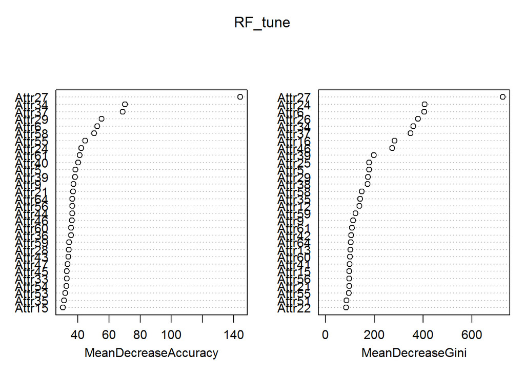

```r
varImpPlot(RF_tune)
```

```r
top_Imp_Attr = as.character(rf_Imp_Attr$Attributes[1:40])
DT_RF_Imp = randomForest(target~.,
                         data=trainsmote[,c(top_Imp_Attr,"target")],
                         keep.forest=TRUE,
                         ntree=500,mtry=19, set.seed(1115)
)
CalScores_response(DT_RF_Imp,testsmote)
```

```
##          Prediction
## Reference    0    1
##         0 2925  900
##         1  246 2724
##
## Recall      :  0.9224219
## Precision   :  0.7647059
## Specificity :  0.7516556
## Accuracy    :  0.8313466
## F1 Score    :  0.8361921
```

- Random Forest Feature Engineering

```r
Feature_Zscore = function(data){
  train_featureEngg = data
  train_featureEngg$Z_Score = NA

  train_featureEngg$Z_Score = 1.2*train_featureEngg$Attr3 +
    1.4*train_featureEngg$Attr6 + 3.3*train_featureEngg$Attr7 +
    0.6*train_featureEngg$Attr8 + 1.0*train_featureEngg$Attr9

  #sum(is.na(train_featureEngg))
  #summary(train_featureEngg)
  std_obj = preProcess(train_featureEngg[, !colnames(train_featureEngg) %in% ("target")],
                       method = c("center", "scale"))
  std_data = predict(std_obj, train_featureEngg)
  #subset(std_data[,c("Attr3","Attr6","Attr7","Attr8","Z_Score")], rownames(std_data)==10049)

  std_data$Z_Score <- ifelse( std_data$Z_Score>2.6, "safe",
                              ifelse(std_data$Z_Score<=2.6 &
                                       std_data$Z_Score>=1.1, "grey_area",
                                     "distress_zone"))
  std_data$Z_Score <- as.factor(std_data$Z_Score)
  return(std_data)
  #table(std_data$Z_Score)
}
#subset(std_data[,c("Attr3","Attr6","Attr7","Attr8","target","Z_Score")], std_data$target ==0 & std_data$Z_Score == "headed_for_bankruptcy")
```

```r
train_data_fet = Feature_Zscore(trainsmote)
test_data_fet = Feature_Zscore(testsmote)

RF_tune_featureng  <- randomForest(target~., data = train_data_fet, ntree = 500, mtry = 19, importance = TRUE, set.seed(2345))
CalScores_response(RF_tune_featureng,test_data_fet)
```

```
##          Prediction
## Reference    0    1
##         0 2938 2782
##         1  233  842
##
## Recall      :  0.9265216
## Precision   :  0.5136364
## Specificity :  0.23234
## Accuracy    :  0.5562914
## F1 Score    :  0.660893
```

# SVM Linear

```r
SVM_linear <- svm(target ~ . , trainsmote,
                 kernel = "linear",
                 probability = TRUE
)
CalScores_response(SVM_linear,testsmote)
```

```
##          Prediction
## Reference    0    1
##         0 1880  614
##         1 1291 3010
##
## Recall      :  0.5928729
## Precision   :  0.7538091
## Specificity :  0.830574
## Accuracy    :  0.7196468
## F1 Score    :  0.6637246
```

# Prediction

```r
bank_testdata = read.csv("test.csv",header = T)
rownames(bank_testdata) <- bank_testdata$ID
#Drop the index column
bank_testdata$ID = NULL
sum(is.na(bank_testdata))
```

```
## [1] 5850
```

```r
bank_testdata = knnimputation(bank_testdata)

ApproxPredict = predict(RF_tune,newdata=bank_testdata, type="class") #0.43
write.csv(x = ApproxPredict, file = "RF_tune_submission1.csv",row.names = T)

test_data_fet = Feature_Zscore(bank_testdata)
ApproxPredict = predict(RF_tune_featureng,newdata=test_data_fet, type="class") #0.11
write.csv(x = ApproxPredict, file = "RF_tune_featureng_submission2.csv",row.names = T)


ApproxPredict = predict(DT_RF_Imp,newdata=bank_testdata, type="class") #0.30
write.csv(x = ApproxPredict, file = "DT_RF_Imp_submission3.csv",row.names = T)

ApproxPredict = predict(DT_RF_Imp,newdata=bank_testdata, type="class") #0.44
write.csv(x = ApproxPredict, file = "DT_RF_Imp_submission4.csv",row.names = T)
tail(ApproxPredict)
```

```
## 42999 43000 43001 43002 43003 43004
##     0     1     1     1     1     1
## Levels: 0 1
```